# Week 3: R Functions

Angela Abraham

2025-10-19

This week we are introducing **R functions** and how to write our own R functions.

Questions to answer:

> Q1. Write a function grade() to determine an overall grade from a vector of student homework assignment scores dropping the lowest single score. If a student misses a homework (i.e. has an NA value) this can be used as a score to be potentially dropped. Your final function should be adquately explained with code comments and be able to work on an example class gradebook such as this one in CSV format: “https://tinyurl.com/gradeinput” [3pts]

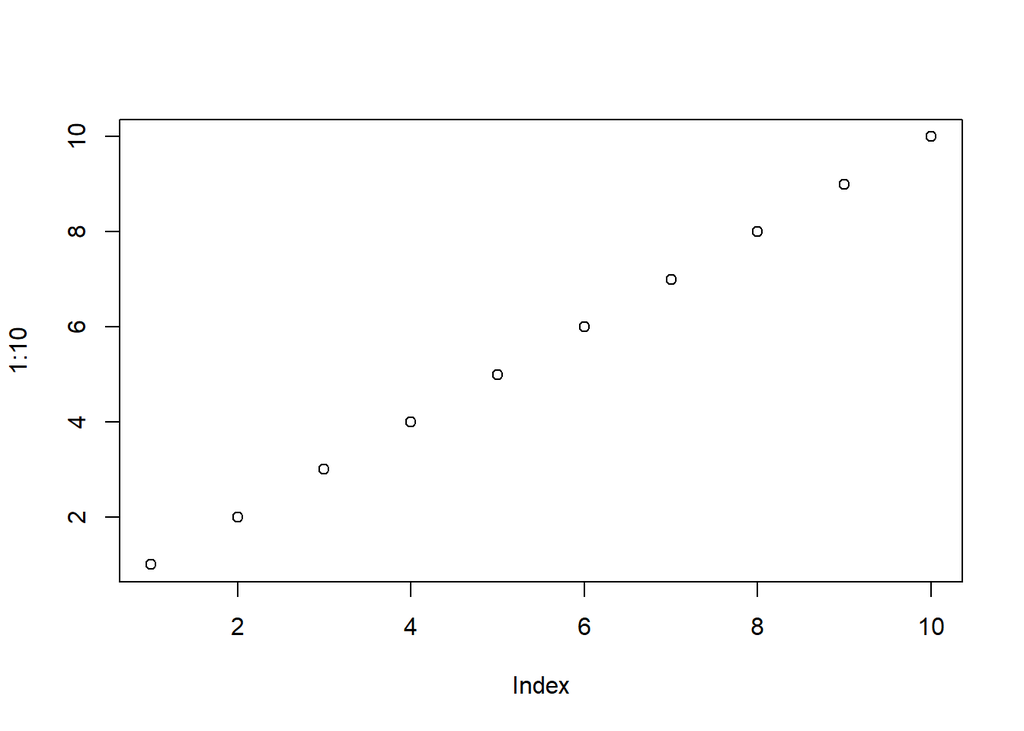

```r
plot(1:10)
```

```r
# Example input vectors to start with
student1 <- c(100, 100, 100, 100, 100, 100, 100, 90)

student2 <- c(100, NA, 90, 90, 90, 90, 97, 80)

student3 <- c(90, NA, NA, NA, NA, NA, NA, NA)
```

Follow the guidelines from class - Write a working snipet of code that solves a simple problem

```r
#straight forward mean()
student1 <- c(100, 100, 100, 100, 100, 100, 100, 90)

mean(student1)
```

```
## [1] 98.75
```

But….We need to drop the lowest score. First we need to identify the lowest score.

```r
#Which element of the vector is the lowest?
which.min(student1)
```

```
## [1] 8
```

What I want is to now drope (i.e. exclude) this lowest score from my mean() calculation.

```r
# This will return everything but the eight elements of the vector
student1[-8]
```

```
## [1] 100 100 100 100 100 100 100
```

Now we can use the answer from which.min() to return all other elements of the vector.

```r
#This is our first working snippet
mean(student1[-which.min(student1)])
```

```
## [1] 100
```

What about the other example students? Will this work for them?

We could try using the na.rm=TRUE for mean but this is not a good approach because it is unfair.

```r
student2 <- c(100, NA, 90, 90, 90, 90, 97, 80)
mean(student2, na.rm=TRUE)
```

```
## [1] 91
```

```r
student3 <- c(90, NA, NA, NA, NA, NA, NA, NA)
mean(student3, na.rm=TRUE)
```

```
## [1] 90
```

Another approach is to mask (i.e replace) all NA values with zero

First we need to find the NA elements of the vector. How do we find the NA elements?

```r
student2 <- c(100, NA, 90, 90, 90, 90, 97, 80)
x<-student2

is.na(x)
```

```
## [1] FALSE  TRUE FALSE FALSE FALSE FALSE FALSE FALSE
```

```r
which(is.na(x))
```

```
## [1] 2
```

Now we have identified the NA elements, now we want to “mask” them. Replace them with zero?

```r
#This does not quite get us there
mean(x[-which(is.na(x))])
```

```
## [1] 91
```

Instead we will make the NA elements zero

```r
#This is useful
x[is.na(x)]<-0
x
```

```
## [1] 100   0  90  90  90  90  97  80
```

```r
mean(x)
```

```
## [1] 79.625
```

Remember we should drop the lowest score now…

```r
x[is.na(x)]<-0
mean(x[-which.min(x)])
```

```
## [1] 91
```

Now we are essentially there with our working snippet.

```r
student3 <- c(90, NA, NA, NA, NA, NA, NA, NA)
x<-student3
x[is.na(x)]<-0
mean(x[-which.min(x)])
```

```
## [1] 12.85714
```

## Now we make our function

Take the snipper and turn it into a function Every function has 3 parts - A name, in our case, ‘grade()’ - Input arguments, a vector of student scores - The body i.e. our working snippet of code